# Prelim analysis

Jono Tuke

2019-07-11

# 1 Read in clean data

```r
TSH_long  <- read_rds("../data/20190711-02_convert_long.rds")
TSH_long
```

```
## # A tibble: 1,386 x 20
##    Paper CvQ   Condition    ID system cohort Thyroid_test     N method
##    <chr> <chr> <chr>     <int> <chr>  <chr>  <chr>        <dbl> <chr>
##  1 Capp… Cont… AF            1 cardi… C4     FT4           2673 Cox PH
##  2 Capp… Cont… AF            1 cardi… C4     TSH           2673 Cox PH
##  3 Capp… Cont… AF            1 cardi… C4     T3            2673 Cox PH
##  4 Capp… Cont… AF            2 cardi… C4     FT4           2673 Cox PH
##  5 Capp… Cont… AF            2 cardi… C4     TSH           2673 Cox PH
##  6 Capp… Cont… AF            2 cardi… C4     T3            2673 Cox PH
##  7 Capp… Cont… CHD           3 cardi… C3     FT4           2215 Cox PH
##  8 Capp… Cont… CHD           3 cardi… C3     TSH           2215 Cox PH
##  9 Capp… Cont… CHD           3 cardi… C3     T3            2215 Cox PH
## 10 Capp… Cont… CHD           4 cardi… C3     FT4           2215 Cox PH
## # … with 1,376 more rows, and 11 more variables: Sig <chr>,
## #   Sophistication <chr>, cov <chr>, total <chr>, inferred <lgl>,
## #   pv <dbl>, bounded <lgl>, OR <dbl>, ORCI <chr>, count <chr>,
## #   countCI <chr>
```

# 2 Visual comparison

## 2.1 Overall

```r
overall_ci  <-
  TSH_long %>%
  filter(!is.na(Sig)) %>%
  group_by(Thyroid_test) %>%
  summarise(
    n_sig = sum(Sig == "Y"),
    N = n(),
    p = n_sig / N,
    lwr = p - 1.96 * sqrt(p * (1 - p) / N),
    upr = p + 1.96 * sqrt(p * (1 - p) / N)
  )
overall_ci
```

```
## # A tibble: 3 x 6
##   Thyroid_test n_sig     N     p   lwr   upr
##   <chr>        <int> <int> <dbl> <dbl> <dbl>
## 1 FT4            260   462 0.563 0.518 0.608
## 2 T3              88   174 0.506 0.431 0.580
## 3 TSH            102   462 0.221 0.183 0.259
```

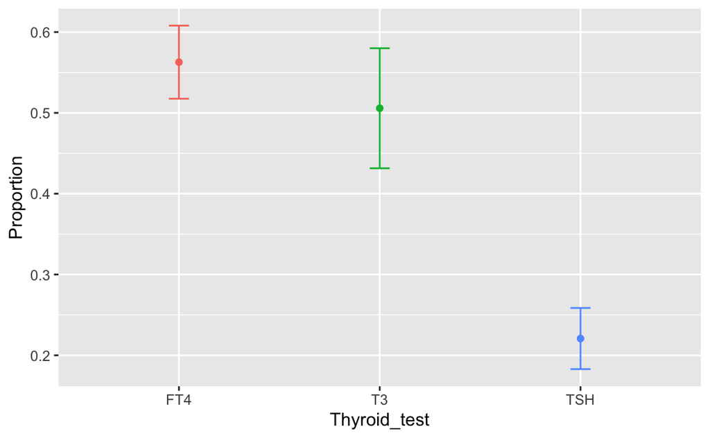

```r
ggplot(overall_ci, aes( Thyroid_test, p, col = Thyroid_test)) +
  geom_point() +
  geom_errorbar(aes(ymin = lwr, ymax = upr), width = 0.1) +
  theme(legend.position = "none") +
  labs(y = "Proportion")
```

## 2.2 System

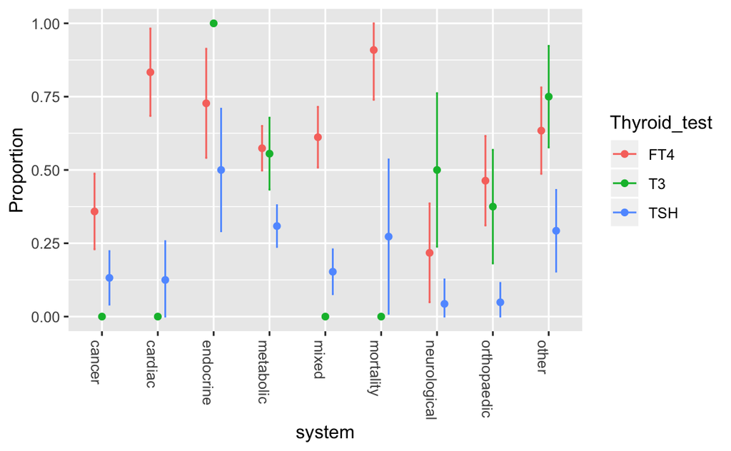

```r
visualise_ci(TSH_long, system)
```

## 2.3 Method

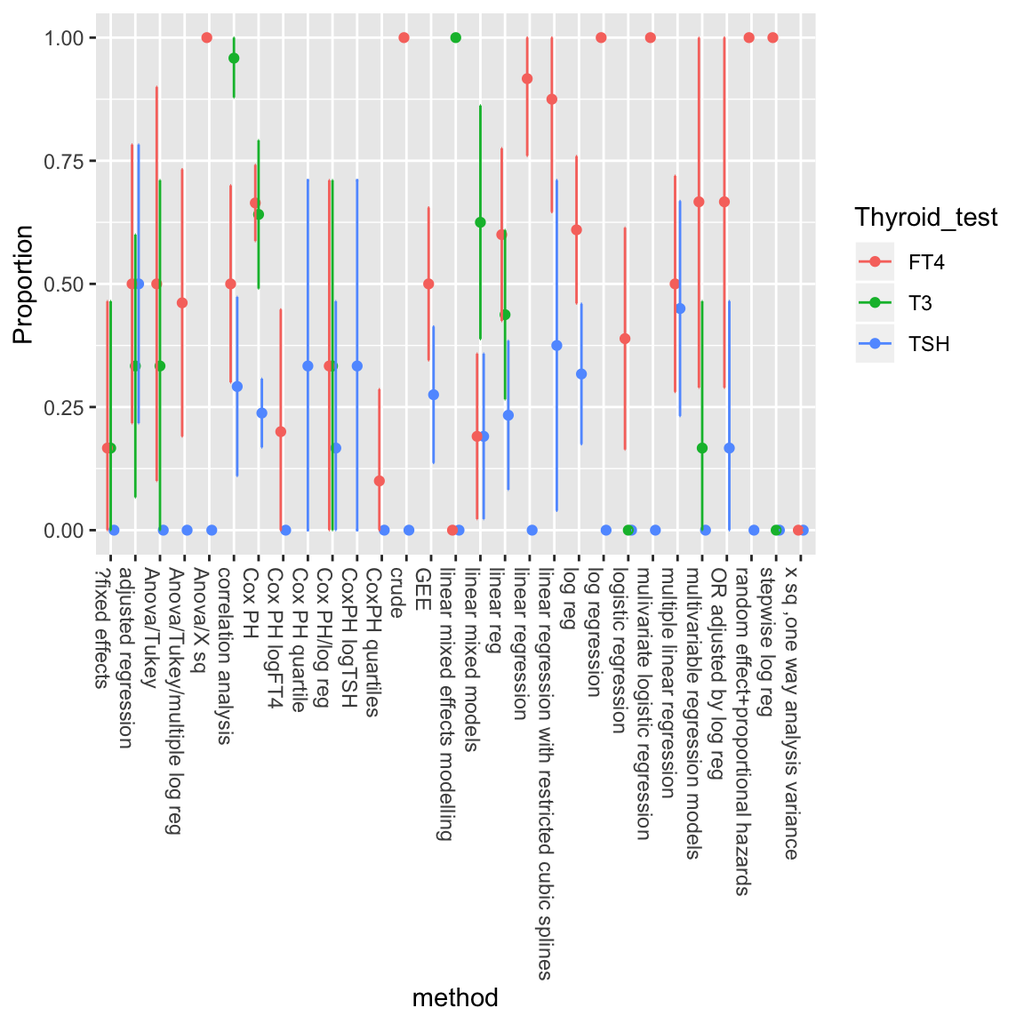

```r
visualise_ci(TSH_long, method)
```

Too many to see a good pattern.

## 2.4 N

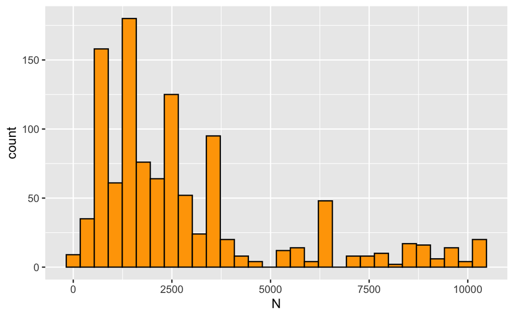

```r
TSH_long %>% ggplot(aes(N)) + geom_histogram(col = "black", fill = "orange")
```

```r
TSH_long  <-
  TSH_long %>%
  mutate(N_bin = cut_number(N, 5))
TSH_long %>% filter(is.na(N_bin))
```

```
## # A tibble: 292 x 21
##    Paper CvQ   Condition    ID system cohort Thyroid_test     N method
##    <chr> <chr> <chr>     <int> <chr>  <chr>  <chr>        <dbl> <chr>
##  1 Capp… Quar… AF           15 cardi… C4     T3              NA <NA>
##  2 Capp… Quar… CHD          16 cardi… C3     T3              NA <NA>
##  3 Capp… Quar… Heart fa…    17 cardi… C5     T3              NA <NA>
##  4 Capp… Quar… mortality    18 morta… C7     T3              NA <NA>
##  5 Capp… Quar… Hip Frac…    19 ortho… C6     T3              NA <NA>
##  6 Capp… Quar… Dementia     20 neuro… C1     T3              NA <NA>
##  7 Chak… Cont… AF preva…    21 cardi… C2     T3              NA <NA>
##  8 Chak… Cont… AF preva…    22 cardi… C2     T3              NA <NA>
##  9 Chak… Cont… AF preva…    23 mixed  C1     T3              NA <NA>
## 10 Chak… Cont… AF preva…    24 mixed  C1     TSH             NA log r…
## # … with 282 more rows, and 12 more variables: Sig <chr>,
## #   Sophistication <chr>, cov <chr>, total <chr>, inferred <lgl>,
## #   pv <dbl>, bounded <lgl>, OR <dbl>, ORCI <chr>, count <chr>,
## #   countCI <chr>, N_bin <fct>
```

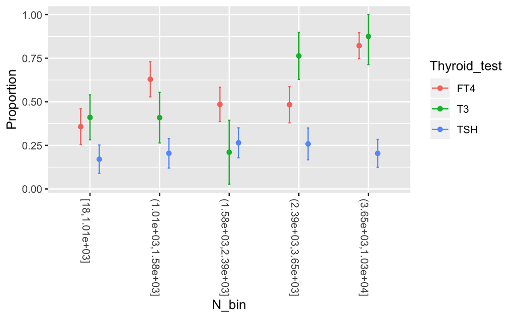

```r
visualise_ci(TSH_long, N_bin)
```

Looks like some interaction effect

## 2.5 Number of covariates in model

```r
TSH_long$n_cov  <- str_split(TSH_long$cov, ",") %>% map(length) %>% unlist()
table(TSH_long$n_cov)
```

```
##
##   1   2   3   4   5   6   7   8   9  10  11  12  13  17
## 548 279 215  60  37  36  12  13  62  17   7  78  19   3
```

Will split into 1, 2, 3, more

```r
TSH_long <-
  TSH_long %>%
  mutate(
    n_cov = case_when(
      n_cov == 1 ~ "1",
      n_cov == 2 ~ "2",
      n_cov == 3 ~ "3",
      TRUE ~ "more"
    )
  )
```

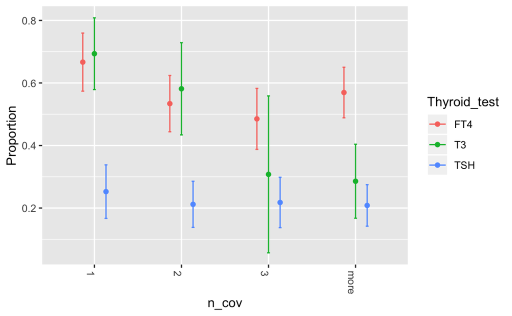

```r
visualise_ci(TSH_long, n_cov)
```

Again some interaction.

# 3 Modelling

We will use a mixed-effect model with the paper ID as a random intercept and thyroid method as a fixed effect.

Need to convert `Sig` to factor. Also remove missing

```r
TSH_long  <-
  TSH_long %>%
  mutate(Sig = factor(Sig))
```

```r
TSH_long <-
  TSH_long %>% filter(!is.na(Sig))
```

Load necessary packages

```r
pacman::p_load(lme4, lmerTest)
```

Start with single fixed effect - thyroid test, and single random intercept (RI) for each paper.

```r
tsh_glmer  <- glmer(Sig ~ Thyroid_test + (1 | Paper), data = TSH_long, family = binomial)
```

Compare model to one without RI.

```r
tsh_glm  <- glm(Sig ~ Thyroid_test, data = TSH_long, family = binomial)
anova(tsh_glmer, tsh_glm)
```

```
## Data: TSH_long
## Models:
## tsh_glm: Sig ~ Thyroid_test
## tsh_glmer: Sig ~ Thyroid_test + (1 | Paper)
##           Df    AIC    BIC  logLik deviance  Chisq Chi Df Pr(>Chisq)
## tsh_glm    3 1368.1 1383.1 -681.07   1362.1
## tsh_glmer  4 1284.0 1304.0 -637.99   1276.0 86.146      1  < 2.2e-16 ***
## ---
## Signif. codes:  0 '***' 0.001 '**' 0.01 '*' 0.05 '.' 0.1 ' ' 1
```

Looks like need RI.

Test for significant differences between tests.

```r
tsh_glmer_null  <- glmer(Sig ~ 1 + (1 | Paper), data = TSH_long, family = binomial)
anova(tsh_glmer, tsh_glmer_null)
```

```
## Data: TSH_long
## Models:
## tsh_glmer_null: Sig ~ 1 + (1 | Paper)
## tsh_glmer: Sig ~ Thyroid_test + (1 | Paper)
##                Df  AIC  BIC  logLik deviance  Chisq Chi Df Pr(>Chisq)
## tsh_glmer_null  2 1418 1428 -707.01     1414
## tsh_glmer       4 1284 1304 -637.99     1276 138.03      2  < 2.2e-16 ***
## ---
## Signif. codes:  0 '***' 0.001 '**' 0.01 '*' 0.05 '.' 0.1 ' ' 1
```

Looks like significant effect of test.

Also check with BIC - smaller is better.

```r
BIC(tsh_glmer_null, tsh_glm, tsh_glmer)
```

```
##                df      BIC
## tsh_glmer_null  2 1428.018
## tsh_glm         3 1383.136
## tsh_glmer       4 1303.991
```

So far best model is fixed effect of test with RI.

```r
summary(tsh_glmer)
```

```
## Generalized linear mixed model fit by maximum likelihood (Laplace
##   Approximation) [glmerMod]
##  Family: binomial  ( logit )
## Formula: Sig ~ Thyroid_test + (1 | Paper)
##    Data: TSH_long
##
##      AIC      BIC   logLik deviance df.resid
##     1284     1304     -638     1276     1094
##
## Scaled residuals:
##     Min      1Q  Median      3Q     Max
## -2.0435 -0.7112 -0.3646  0.7302  3.3179
##
## Random effects:
##  Groups Name        Variance Std.Dev.
##  Paper  (Intercept) 0.6338   0.7961
## Number of obs: 1098, groups:  Paper, 35
##
## Fixed effects:
##                 Estimate Std. Error z value Pr(>|z|)
## (Intercept)       0.3172     0.1766   1.797   0.0724 .
## Thyroid_testT3   -0.2229     0.2118  -1.052   0.2928
## Thyroid_testTSH  -1.7172     0.1595 -10.769   <2e-16 ***
## ---
## Signif. codes:  0 '***' 0.001 '**' 0.01 '*' 0.05 '.' 0.1 ' ' 1
##
## Correlation of Fixed Effects:
##             (Intr) Thy_T3
## Thyrd_tstT3 -0.245
## Thyrd_tsTSH -0.379  0.293
```

From this - look at fixed effect output. We have that TSH has a signicantly smaller probability of significance compared to T4. T3 and T4 are not significantly different.

## 3.1 Try adding in other covariates.

### 3.1.1 System

```r
system_models  <- get_cov("system")
system_models %>% arrange(BIC) %>% knitr::kable()
```

| sigma | logLik | AIC | BIC | deviance | df.residual | null.deviance | df.null | converge | models |
| --- | --- | --- | --- | --- | --- | --- | --- | --- | --- |
| 1 | -637.9930 | 1283.986 | 1303.991 | 1204.165 | 1094 | NA | NA | TRUE | test + RI |
| 1 | -625.7613 | 1275.523 | 1335.538 | 1185.558 | 1086 | NA | NA | TRUE | test + main + RI |
| NA | -640.3934 | 1302.787 | 1357.800 | 1280.787 | 1087 | 1486.25 | 1097 | TRUE | test + main |
| 1 | -590.2743 | 1236.549 | 1376.584 | 1113.024 | 1070 | NA | NA | FALSE | interaction + RI |
| NA | -681.0661 | 1368.132 | 1383.136 | 1362.132 | 1095 | 1486.25 | 1097 | TRUE | test |
| NA | -603.3479 | 1260.696 | 1395.729 | 1206.696 | 1071 | 1486.25 | 1097 | TRUE | interaction |

### 3.1.2 N of subjects

```r
N_models  <- get_cov("N_bin")
N_models %>% arrange(BIC) %>% knitr::kable()
```

| sigma | logLik | AIC | BIC | deviance | df.residual | null.deviance | df.null | converge | models |
| --- | --- | --- | --- | --- | --- | --- | --- | --- | --- |
| 1 | -637.9930 | 1283.986 | 1303.991 | 1204.165 | 1094 | NA | NA | TRUE | test + RI |
| 1 | -630.3294 | 1276.659 | 1316.639 | 1195.030 | 1086 | NA | NA | TRUE | test + main + RI |
| 1 | -607.8741 | 1247.748 | 1327.710 | 1146.155 | 1078 | NA | NA | FALSE | interaction + RI |
| NA | -660.3875 | 1334.775 | 1369.758 | 1320.775 | 1087 | 1482.021 | 1093 | TRUE | test + main |
| NA | -636.7321 | 1303.464 | 1378.428 | 1273.464 | 1079 | 1482.021 | 1093 | TRUE | interaction |
| NA | -681.0661 | 1368.132 | 1383.136 | 1362.132 | 1095 | 1486.250 | 1097 | TRUE | test |

### 3.1.3 Number of covariates

```r
n_cov_models  <- get_cov("n_cov")
n_cov_models %>% arrange(BIC) %>% knitr::kable()
```

| sigma | logLik | AIC | BIC | deviance | df.residual | null.deviance | df.null | converge | models |
| --- | --- | --- | --- | --- | --- | --- | --- | --- | --- |
| 1 | -637.9930 | 1283.986 | 1303.991 | 1204.165 | 1094 | NA | NA | TRUE | test + RI |
| 1 | -635.6437 | 1285.287 | 1320.296 | 1198.987 | 1091 | NA | NA | TRUE | test + main + RI |
| 1 | -629.1435 | 1284.287 | 1349.303 | 1185.834 | 1085 | NA | NA | TRUE | interaction + RI |
| NA | -681.0661 | 1368.132 | 1383.136 | 1362.132 | 1095 | 1486.25 | 1097 | TRUE | test |
| NA | -672.5756 | 1357.151 | 1387.159 | 1345.151 | 1092 | 1486.25 | 1097 | TRUE | test + main |
| NA | -664.3731 | 1352.746 | 1412.761 | 1328.746 | 1086 | 1486.25 | 1097 | TRUE | interaction |

# 4 Model to take into account cohorts

Looked at the lme4 paper

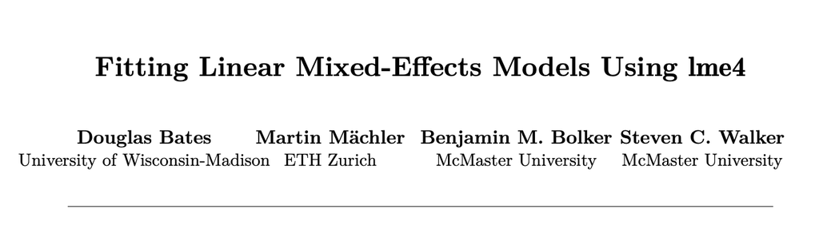

The notation is given in Table 2 of the paper:

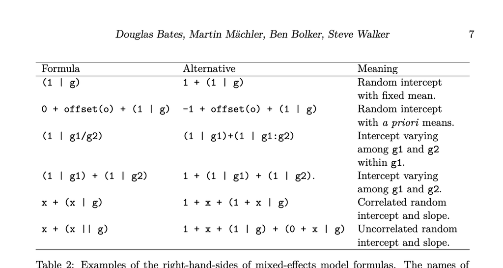

Looks like we want

```
(1 | paper/cohort)
```

```r
tsh_glmer_M_paperRI  <- glmer(Sig ~ Thyroid_test + (1 | Paper),
                              data = TSH_long, family = binomial)
tsh_glmer_M_paper_cohort_RI  <- glmer(Sig ~ Thyroid_test + (1 | Paper / cohort),
                                      data = TSH_long, family = binomial)
tsh_glmer_M_no_test  <- glmer(Sig ~ 1 + (1 | Paper / cohort),
                              data = TSH_long, family = binomial)
```

First test for whether need cohort RI:

```r
anova(tsh_glmer_M_paperRI, tsh_glmer_M_paper_cohort_RI)
```

```
## Data: TSH_long
## Models:
## tsh_glmer_M_paperRI: Sig ~ Thyroid_test + (1 | Paper)
## tsh_glmer_M_paper_cohort_RI: Sig ~ Thyroid_test + (1 | Paper/cohort)
##                             Df    AIC    BIC  logLik deviance  Chisq
## tsh_glmer_M_paperRI          4 1284.0 1304.0 -637.99   1276.0
## tsh_glmer_M_paper_cohort_RI  5 1256.1 1281.1 -623.03   1246.1 29.928
##                             Chi Df Pr(>Chisq)
## tsh_glmer_M_paperRI
## tsh_glmer_M_paper_cohort_RI      1  4.483e-08 ***
## ---
## Signif. codes:  0 '***' 0.001 '**' 0.01 '*' 0.05 '.' 0.1 ' ' 1
```

Small p-value so looks like we need cohort and paper RI.

No test for significant effect of test

```r
anova(tsh_glmer_M_paper_cohort_RI, tsh_glmer_M_no_test)
```

```
## Data: TSH_long
## Models:
## tsh_glmer_M_no_test: Sig ~ 1 + (1 | Paper/cohort)
## tsh_glmer_M_paper_cohort_RI: Sig ~ Thyroid_test + (1 | Paper/cohort)
##                             Df    AIC    BIC  logLik deviance  Chisq
## tsh_glmer_M_no_test          3 1400.7 1415.7 -697.34   1394.7
## tsh_glmer_M_paper_cohort_RI  5 1256.1 1281.1 -623.03   1246.1 148.62
##                             Chi Df Pr(>Chisq)
## tsh_glmer_M_no_test
## tsh_glmer_M_paper_cohort_RI      2  < 2.2e-16 ***
## ---
## Signif. codes:  0 '***' 0.001 '**' 0.01 '*' 0.05 '.' 0.1 ' ' 1
```

So still significant effect of type of test.

Look at effect of test.

```r
summary(tsh_glmer_M_paper_cohort_RI)
```

```
## Generalized linear mixed model fit by maximum likelihood (Laplace
##   Approximation) [glmerMod]
##  Family: binomial  ( logit )
## Formula: Sig ~ Thyroid_test + (1 | Paper/cohort)
##    Data: TSH_long
##
##      AIC      BIC   logLik deviance df.resid
##   1256.1   1281.1   -623.0   1246.1     1093
##
## Scaled residuals:
##     Min      1Q  Median      3Q     Max
## -2.5062 -0.6277 -0.3253  0.6730  3.7654
##
## Random effects:
##  Groups       Name        Variance Std.Dev.
##  cohort:Paper (Intercept) 0.7336   0.8565
##  Paper        (Intercept) 0.6832   0.8266
## Number of obs: 1098, groups:  cohort:Paper, 102; Paper, 35
##
## Fixed effects:
##                 Estimate Std. Error z value Pr(>|z|)
## (Intercept)       0.3841     0.2118   1.814   0.0697 .
## Thyroid_testT3   -0.2391     0.2173  -1.101   0.2711
## Thyroid_testTSH  -1.8703     0.1701 -10.995   <2e-16 ***
## ---
## Signif. codes:  0 '***' 0.001 '**' 0.01 '*' 0.05 '.' 0.1 ' ' 1
##
## Correlation of Fixed Effects:
##             (Intr) Thy_T3
## Thyrd_tstT3 -0.211
## Thyrd_tsTSH -0.339  0.296
```

As before probability of significance is significantly lower than FT4 and T3.

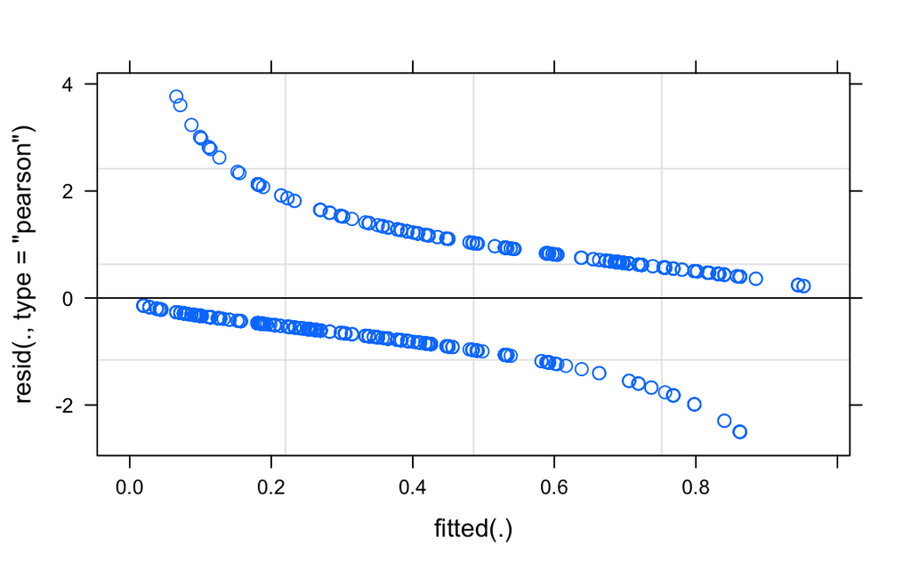

```r
plot(tsh_glmer_M_paper_cohort_RI)
```

# 5 Model to take into account style

Will be similar to above. First examine possible styles

```r
TSH_long %>%
  count(CvQ) %>%
  knitr::kable()
```

[output not shown]

Need to talk to NB about which to keep.

# 6 Model to take into account sophistication

```r
TSH_long %>%
  count(Sophistication)
```

```
## # A tibble: 4 x 2
##   Sophistication     n
##   <chr>          <int>
## 1 Crude            229
## 2 High             212
## 3 Low              166
## 4 Medium           491
```

```r
TSH_long_noNA  <-
  TSH_long %>%
  filter(!is.na(Sophistication))
```

Fit all models

```r
tsh_glmer_M_paperRI  <- glmer(Sig ~ Thyroid_test + (1 | Paper),
                              data = TSH_long_noNA, family = binomial)
tsh_glmer_M_paper_soph_RI  <- glmer(Sig ~ Thyroid_test + (1 | Paper / Sophistication),
                                      data = TSH_long_noNA, family = binomial)
tsh_glmer_M_no_test  <- glmer(Sig ~ 1 + (1 | Paper / cohort),
                              data = TSH_long_noNA, family = binomial)
```

First test for whether need sophistication RI:

```r
anova(tsh_glmer_M_paperRI, tsh_glmer_M_paper_soph_RI)
```

```
## Data: TSH_long_noNA
## Models:
## tsh_glmer_M_paperRI: Sig ~ Thyroid_test + (1 | Paper)
## tsh_glmer_M_paper_soph_RI: Sig ~ Thyroid_test + (1 | Paper/Sophistication)
##                           Df    AIC    BIC  logLik deviance  Chisq Chi Df
## tsh_glmer_M_paperRI        4 1284.0 1304.0 -637.99   1276.0
## tsh_glmer_M_paper_soph_RI  5 1283.2 1308.2 -636.62   1273.2 2.7542      1
##                           Pr(>Chisq)
## tsh_glmer_M_paperRI
## tsh_glmer_M_paper_soph_RI      0.097 .
## ---
## Signif. codes:  0 '***' 0.001 '**' 0.01 '*' 0.05 '.' 0.1 ' ' 1
```

Not significant so not needed.

# 7 Extra treatment

## 7.1 Add in variable

So we will split T3 into T3_total amnd T3_free

```r
TSH_long <-
  TSH_long %>%
  mutate(
    Thyroid_test_4 = ifelse(
      is.na(total),
      Thyroid_test,
      paste0(Thyroid_test, "_",total)
    )
  )
```

## 7.2 CIs

```r
overall_ci  <-
  TSH_long %>%
  filter(!is.na(Sig)) %>%
  group_by(Thyroid_test_4) %>%
  summarise(
    n_sig = sum(Sig == "Y"),
    N = n(),
    p = n_sig / N,
    lwr = p - 1.96 * sqrt(p * (1 - p) / N),
    upr = p + 1.96 * sqrt(p * (1 - p) / N)
  )
overall_ci
```

```
## # A tibble: 4 x 6
##   Thyroid_test_4 n_sig     N     p   lwr   upr
##   <chr>          <int> <int> <dbl> <dbl> <dbl>
## 1 FT4              260   462 0.563 0.518 0.608
## 2 T3_Free           40   109 0.367 0.276 0.457
## 3 T3_Total          48    65 0.738 0.632 0.845
## 4 TSH              102   462 0.221 0.183 0.259
```

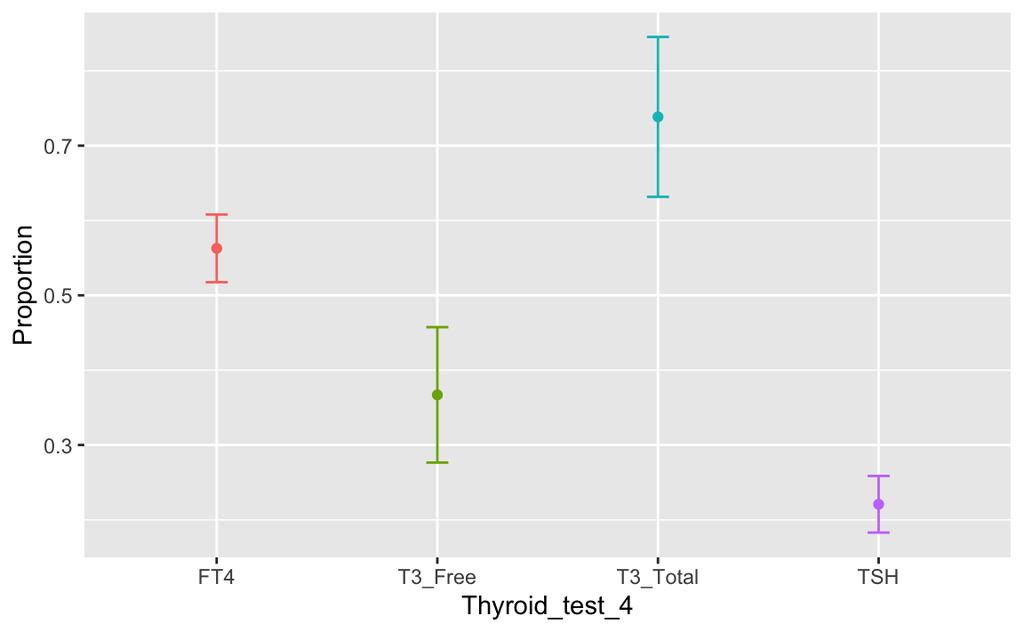

```r
ggplot(overall_ci, aes( Thyroid_test_4, p, col = Thyroid_test_4)) +
  geom_point() +
  geom_errorbar(aes(ymin = lwr, ymax = upr), width = 0.1) +
  theme(legend.position = "none") +
  labs(y = "Proportion")
```

## 7.3 Modelling

Will remove single T3

```r
TSH_long_noT3  <- TSH_long %>% filter(Thyroid_test_4 != "T3")
```

```r
tsh_glmer  <- glmer(Sig ~ Thyroid_test_4 + (1 | Paper), data = TSH_long_noT3, family = binomial)
tsh_glm  <- glm(Sig ~ Thyroid_test_4, data = TSH_long_noT3, family = binomial)
anova(tsh_glmer, tsh_glm)
```

```
## Data: TSH_long_noT3
## Models:
## tsh_glm: Sig ~ Thyroid_test_4
## tsh_glmer: Sig ~ Thyroid_test_4 + (1 | Paper)
##           Df    AIC    BIC  logLik deviance  Chisq Chi Df Pr(>Chisq)
## tsh_glm    4 1346.9 1367.0 -669.47   1338.9
## tsh_glmer  5 1282.4 1307.4 -636.18   1272.4 66.578      1  3.364e-16 ***
## ---
## Signif. codes:  0 '***' 0.001 '**' 0.01 '*' 0.05 '.' 0.1 ' ' 1
```

```r
tsh_glmer_null  <- glmer(Sig ~ 1 + (1 | Paper), data = TSH_long_noT3, family = binomial)
anova(tsh_glmer, tsh_glmer_null)
```

```
## Data: TSH_long_noT3
## Models:
## tsh_glmer_null: Sig ~ 1 + (1 | Paper)
## tsh_glmer: Sig ~ Thyroid_test_4 + (1 | Paper)
##                Df    AIC    BIC  logLik deviance  Chisq Chi Df Pr(>Chisq)
## tsh_glmer_null  2 1418.0 1428.0 -707.01   1414.0
## tsh_glmer       5 1282.4 1307.4 -636.18   1272.4 141.65      3  < 2.2e-16
##
## tsh_glmer_null
## tsh_glmer      ***
## ---
## Signif. codes:  0 '***' 0.001 '**' 0.01 '*' 0.05 '.' 0.1 ' ' 1
```

```r
summary(tsh_glmer)
```

```
## Generalized linear mixed model fit by maximum likelihood (Laplace
##   Approximation) [glmerMod]
##  Family: binomial  ( logit )
## Formula: Sig ~ Thyroid_test_4 + (1 | Paper)
##    Data: TSH_long_noT3
##
##      AIC      BIC   logLik deviance df.resid
##   1282.4   1307.4   -636.2   1272.4     1093
##
## Scaled residuals:
##     Min      1Q  Median      3Q     Max
## -2.2167 -0.7134 -0.3855  0.7339  3.2755
##
## Random effects:
##  Groups Name        Variance Std.Dev.
##  Paper  (Intercept) 0.5928   0.7699
## Number of obs: 1098, groups:  Paper, 35
##
## Fixed effects:
##                        Estimate Std. Error z value Pr(>|z|)
## (Intercept)              0.3189     0.1728   1.846   0.0649 .
## Thyroid_test_4T3_Free   -0.4981     0.2579  -1.931   0.0535 .
## Thyroid_test_4T3_Total   0.3182     0.3626   0.878   0.3802
## Thyroid_test_4TSH       -1.6976     0.1585 -10.708   <2e-16 ***
## ---
## Signif. codes:  0 '***' 0.001 '**' 0.01 '*' 0.05 '.' 0.1 ' ' 1
##
## Correlation of Fixed Effects:
##             (Intr) T__4T3_F T__4T3_T
## Thyr__4T3_F -0.208
## Thyr__4T3_T -0.139  0.055
## Thyrd__4TSH -0.384  0.208    0.208
```

```r
pacman::p_load(multcomp)
summary(glht(tsh_glmer, linfct = mcp(Thyroid_test_4 = "Tukey")))
```

```
##
##   Simultaneous Tests for General Linear Hypotheses
##
## Multiple Comparisons of Means: Tukey Contrasts
##
##
## Fit: glmer(formula = Sig ~ Thyroid_test_4 + (1 | Paper), data = TSH_long_noT3,
##     family = binomial)
##
## Linear Hypotheses:
##                         Estimate Std. Error z value Pr(>|z|)
## T3_Free - FT4 == 0       -0.4981     0.2579  -1.931    0.198
## T3_Total - FT4 == 0       0.3182     0.3626   0.878    0.803
## TSH - FT4 == 0           -1.6976     0.1585 -10.708   <0.001 ***
## T3_Total - T3_Free == 0   0.8163     0.4333   1.884    0.217
## TSH - T3_Free == 0       -1.1995     0.2732  -4.391   <0.001 ***
## TSH - T3_Total == 0      -2.0158     0.3642  -5.534   <0.001 ***
## ---
## Signif. codes:  0 '***' 0.001 '**' 0.01 '*' 0.05 '.' 0.1 ' ' 1
## (Adjusted p values reported -- single-step method)
```

# 8 Look at selected systems

```r
TSH_long <-
  TSH_long %>%
  mutate(high_low = case_when(
    str_detect(Condition, "AF") ~ "high",
    str_detect(Condition, "low bone density") ~ "high",
    system == "cancer" ~ "high",
    str_detect(Condition, "fatty liver") ~ "low",
    system == "metabolic" ~ "low",
    TRUE ~ "neither"
  ))
```

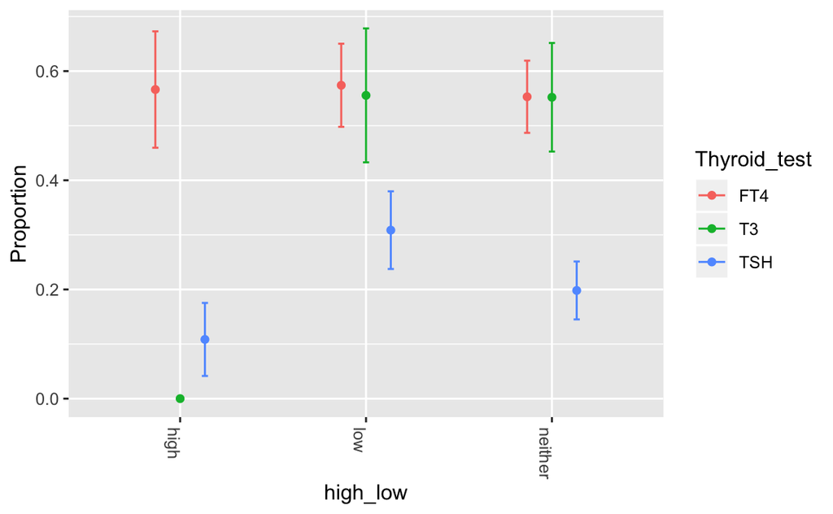

```r
visualise_ci(TSH_long, high_low)
```

```r
high_low_models  <- get_cov("high_low")
high_low_models %>% arrange(BIC) %>% knitr::kable()
```

| sigma | logLik | AIC | BIC | deviance | df.residual | null.deviance | df.null | converge | models |
| --- | --- | --- | --- | --- | --- | --- | --- | --- | --- |
| 1 | -637.9930 | 1283.986 | 1303.991 | 1204.165 | 1094 | NA | NA | TRUE | test + RI |
| 1 | -637.5235 | 1287.047 | 1317.054 | 1202.240 | 1092 | NA | NA | TRUE | test + main + RI |
| 1 | -624.8932 | 1269.786 | 1319.799 | 1175.495 | 1088 | NA | NA | FALSE | interaction + RI |
| NA | -681.0661 | 1368.132 | 1383.136 | 1362.132 | 1095 | 1486.25 | 1097 | TRUE | test |
| NA | -675.1245 | 1360.249 | 1385.255 | 1350.249 | 1093 | 1486.25 | 1097 | TRUE | test + main |
| NA | -662.4324 | 1342.865 | 1387.876 | 1324.865 | 1089 | 1486.25 | 1097 | TRUE | interaction |